# Reproducible Research: Peer Assessment 1

Kajlinko

2022-12-01

THANKS FOR TAKING THE TIME TO REVIEW THIS!

## Loading and preprocessing the data

Data was loaded from the .zip file downloaded with from the assignment git repository using the R `unzip()` and `read.csv()` functions. They were stored in a variable for future analyses.

```r
activity <- read.csv(unzip("activity.zip"))
```

## What is mean total number of steps taken per day?

The mean number of steps per day were calculated in two stages, first the total daily number of steps were calculated. The `dplyr` package was used to facilitate grouping, before summing the steps for each date. NAs were ignored as per the instructions, though this may introduce error.

```r
library(dplyr)
dailyTotals <- activity %>%
  group_by(date) %>%
  summarise(
  sumSteps = sum(steps, na.rm = TRUE)
  )
```

Subsequently, the mean and median were calculated. The result was rounded to the nearest integer, as fractional steps make little sense in the real world.

```r
meanDaily <- round(mean(dailyTotals$sumSteps), 0)
medianDaily <- round(median(dailyTotals$sumSteps), 0)
print(meanDaily)
```

```
## [1] 9354
```

```r
print(medianDaily)
```

```
## [1] 10395
```

I thought about this section a lot and DID NOT PRODUCE A HISTOGRAM. A histogram plots the frequency that a given continuous variable appears, so it is not the natural choice of plot in this instance. It is most useful for examining the distribution of a data set. A bar plot or a scatter graph would be more suitable for plotting total steps per day, as we are plotting one discrete variable on the x-axis and one continuous variable on the y-axis.

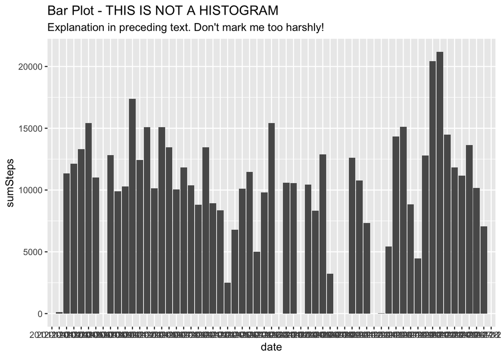

```r
library(ggplot2)

ggplot(dailyTotals, aes(x = date, y = sumSteps)) +
  geom_col() +
  ggtitle("Bar Plot - THIS IS NOT A HISTOGRAM",
          subtitle = "Explanation in preceding text. Don't mark me too harshly!")
```

## What is the average daily activity pattern?

To get an idea of the average daily activity pattern, the data was grouped by time interval (representing the day split into 5 minute intervals) and averaged across all days.

This was then plotted on a time-series line graph in `ggplot2`.

The maximum average value was calculated with `which.max()`.

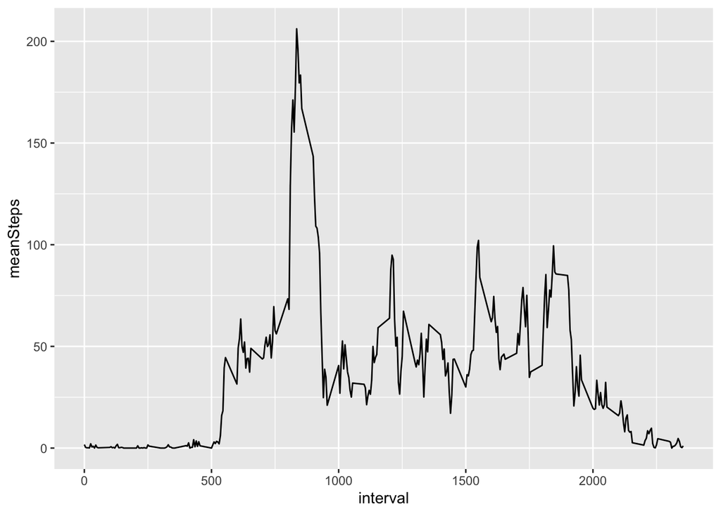

```r
timeMeans <- activity %>%
  group_by(interval) %>%
  summarise(
    meanSteps = mean(steps, na.rm = TRUE)
  )

ggplot(timeMeans, aes(x = interval, y = meanSteps)) +
  geom_line()
```

```r
print(timeMeans$interval[which.max(timeMeans$meanSteps)])
```

```
## [1] 835
```

## Imputing missing values

Missing values were identified with the `is.na()` function. They were counted using the `sum()` function.

```r
sum(is.na(activity$steps))
```

```
## [1] 2304
```

To crudely impute the missing values the mean value corresponding to the time point of a missing value was substituted.

A new data frame `imputeActivity` was created and NA values were replaced using a for loop. Values were replaced with corresponding mean values from the `timeMeans` data frame.

```r
imputeActivity <- activity

for(i in 1:nrow(imputeActivity)) {
  rem <- i %% 288
  if(rem == 0) {
    rem <- 288
  }
  if(is.na(imputeActivity$steps[i])) {
    imputeActivity$steps[i] <- timeMeans$meanSteps[rem]
  }
}

sum(is.na(imputeActivity$steps))
```

```
## [1] 0
```

The new mean and median were calculated as before. Please see previous reasoning for choice of a bar chart over a histogram.

```r
imputeTotals <- imputeActivity %>%
  group_by(date) %>%
  summarise(
  sumSteps = sum(steps, na.rm = TRUE)
  )

imputeMean <- round(mean(imputeTotals$sumSteps), 0)
imputeMedian <- round(median(imputeTotals$sumSteps), 0)
print(imputeMean)
```

```
## [1] 10766
```

```r
print(imputeMedian)
```

```
## [1] 10766
```

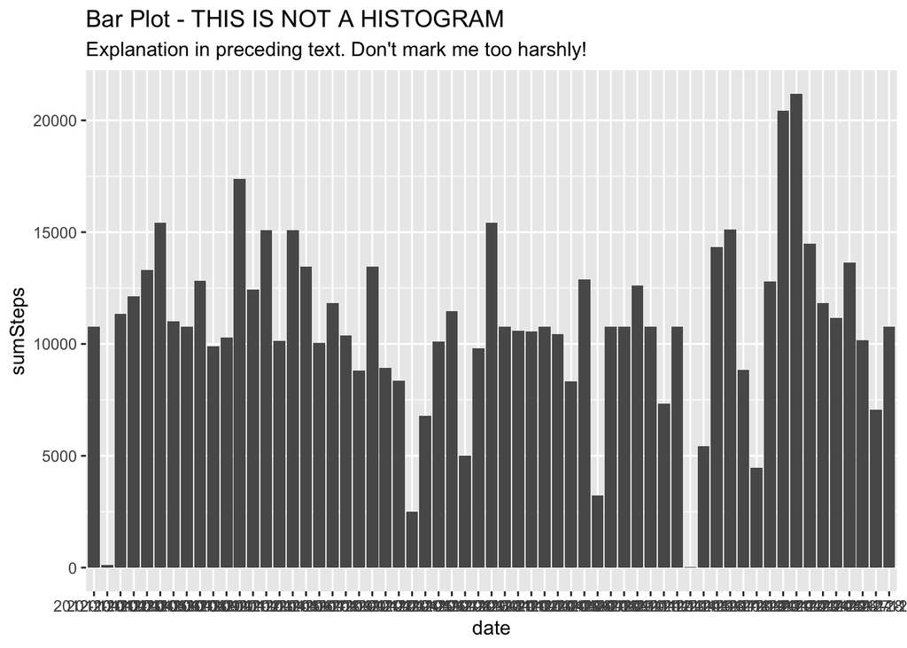

```r
ggplot(imputeTotals, aes(x = date, y = sumSteps)) +
  geom_col() +
  ggtitle("Bar Plot - THIS IS NOT A HISTOGRAM",
          subtitle = "Explanation in preceding text. Don't mark me too harshly!")
```

The mean and median values have both increased, as we would expect.

## Are there differences in activity patterns between weekdays and weekends?

This question was answered using the `lubridate` package and `ggplot` as before.

```r
library(lubridate)
activity$weekday <- weekdays(as_date(activity$date))

weekdayTotals <- activity %>%
  group_by(weekday) %>%
  summarise(
    sumSteps = sum(steps, na.rm = TRUE),
    meanSteps = mean(steps, na.rm = TRUE)
  )

weekdayTotals$weekday <- factor(weekdayTotals$weekday,
                                 levels=c("Monday", "Tuesday", "Wednesday",
                                          "Thursday", "Friday", "Saturday",
                                          "Sunday"))

weekdayTotals[order(weekdayTotals$weekday),]
```

```
## # A tibble: 7 × 3
##   weekday   sumSteps meanSteps
##   <fct>        <int>     <dbl>
## 1 Monday       69824      34.6
## 2 Tuesday      80546      31.1
## 3 Wednesday    94326      40.9
## 4 Thursday     65702      28.5
## 5 Friday       86518      42.9
## 6 Saturday     87748      43.5
## 7 Sunday       85944      42.6
```

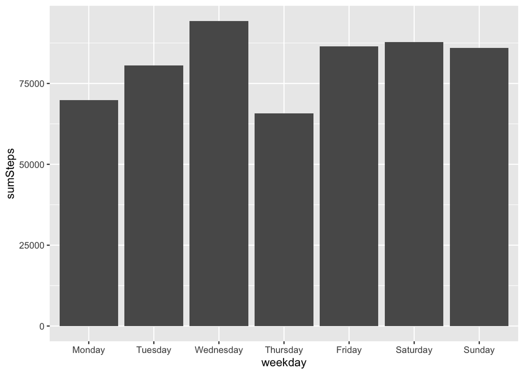

```r
ggplot(weekdayTotals, aes(x = weekday, y = sumSteps)) +
  geom_col()
```